# Projet Rstudio

HENRI Paul et DUMONT ROTY Pierre

2023 - 2024

# 1 Introduction

À l’automne 2023, un *sondage* a été réalisé via **Célène** auprès des étudiantes et étudiants de Licence d’Économie et de L1 Gestion de l’[université de Tours](https://www.univ-tours.fr/). Ce *sondage* a été régulièrement mis à jour, et nous disposons ici de la version finale datant du 24/11/2023.

Grâce à ces résultats et à la participation de 208 étudiant.e.s, nous allons pouvoir exploiter ces données afin de créer des tableaux et des graphiques qui nous permettront de les visualiser plus facilement.

## 1.1 Problématique

Les étudiants ont été en mesure de répondre à de nombreuses questions, dont une qui nous a particulièrement intéressés :

*Fumez-vous du tabac ?*

À partir de cette réponse à choix multiples, nous nous sommes posé la question suivante :

**Qu’est-ce qui distingue un fumeur d’un non-fumeur ?**

Nous avons alors étudié plusieurs questions et cherché à savoir si le fumeur présentait des caractéristiques distinctes par rapport au non-fumeur.

## 1.2 Le fumeur

Nous allons dans un premier temps nous concentrer sur le fumeur :

Comment le définir, et qu’est-ce qui fait qu’un étudiant sera considéré comme un *fumeur* ?

| Statut | Effectif |
| --- | --- |
| Non et je n’ai jamais vraiment fumé | 167 |
| Non, j’ai arrêté | 4 |
| Oui occasionnellement | 24 |
| Oui, régulièrement | 13 |

Les 4 réponses possibles du questionnaire étaient celles-ci. On observe qu’une majorité des étudiants n’ont jamais fumé et que seuls 4 individus avaient arrêté au moment du sondage. Cependant, pour l’analyse du questionnaire, nous allons créer une variable définie comme suit :

- L’étudiant est un fumeur ou un ancien fumeur.
- L’étudiant n’a jamais vraiment fumé.

Nous avons choisi cette approche, car certaines questions concernent le passé de l’individu, et il était nécessaire de les comptabiliser.

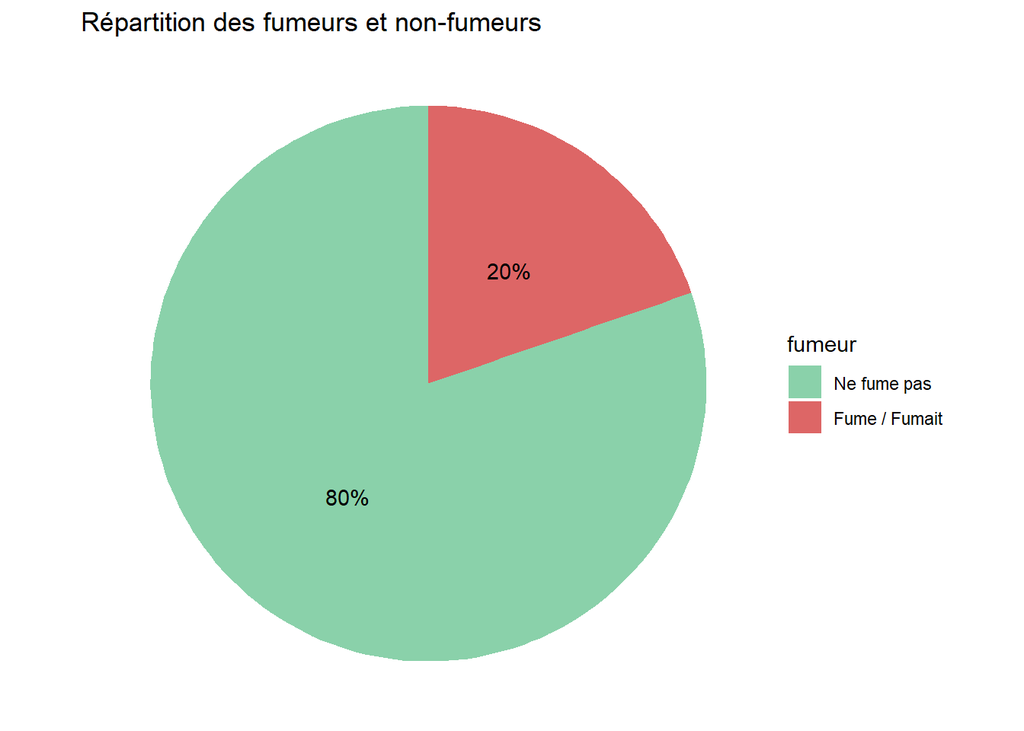

| fumeur | N | % |
| --- | --- | --- |
| Ne fume pas | 167 | 80.3 |
| Fume / Fumait | 41 | 19.7 |

On observe que le tabac a rendu addict 19,7 % des répondants.

Peut-on trouver une liaison entre cette répartition et les réponses au questionnaire ?

# 2 Étude des données

## 2.1 Statut par rapport au genre

Fumeurs et fumeuses suivant le genre

|  | Ne fume pas | Fume / Fumait | Sum |
| --- | --- | --- | --- |
| Féminin | 61 | 13 | 74 |
| Masculin | 106 | 28 | 134 |
| Sum | 167 | 41 | 208 |

On note que les hommes fumeurs sont majoritaires par rapport aux femmes fumeuses, tant en nombre qu’en proportion, puisque **21 %** des hommes fument (contre **17 %** chez les femmes).

## 2.2 Spécialités du BAC

Nous allons maintenant nous intéresser aux filières choisies par les étudiants. Certains ont obtenu leur BAC en 2020, tandis que d’autres l’ont obtenu avant, à une époque où la réforme n’était pas encore en place, ce qui explique la présence des filières S, ES et L.

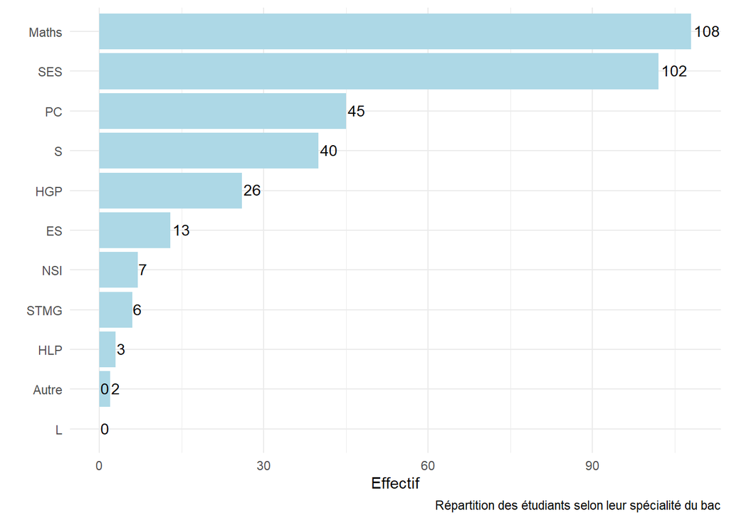

Nous avons retranscrit les données dans un histogramme qui met en évidence la forte présence des mathématiques (108) et de la SES (102) au sein de la Licence d’Économie.

Face au grand nombre de spécialités, nous avons regroupé ces dernières en deux catégories afin de déterminer leur relation avec le statut de fumeur :

- **Les spécialités littéraires :**

  Ce groupe inclut les matières ayant un faible niveau de mathématiques et se concentrant davantage sur l’étude de documents et l’analyse de textes.
- **Les spécialités scientifiques :**

  Ce groupe comprend toutes les spécialités à orientation scientifique, telles que la spécialité mathématiques ou l’ancienne spécialité S, qui englobait à l’époque les maths, SVT et PC.

Type de spécialité selectionné parmis les étudiants

| Type de spécialité | Effectif |
| --- | --- |
| spécialité littéraire | 44 |
| spécialité scientifique | 149 |

La répartition des étudiants est majoritairement scientifique, comme le montre le tableau d’effectifs global. Le détail des effectifs selon le type de spécialité est le suivant :

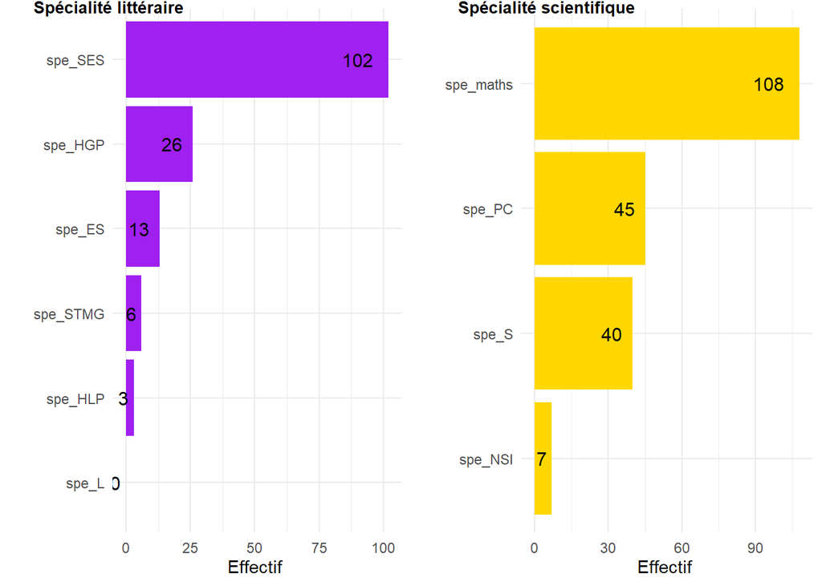

Ce dernier vient de nouveau renforcer l’omniprésence des mathématiques et de la SES dans les enseignements choisis par les étudiants.

Mais que font les fumeurs dans tout cela ? Quels ont été leurs parcours tout au long du lycée ?

C’est grâce au tableau en barres comparant les fumeurs et les deux types de spécialité que nous pourrons le découvrir.

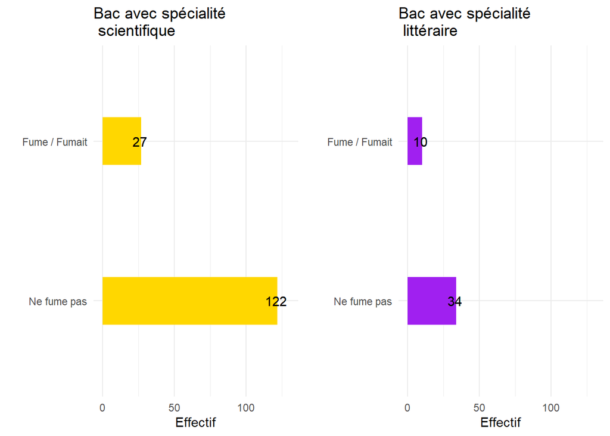

## 2.3 Consommation mensuelle d’alcool

L’une des questions a porté sur la consommation d’alcool par mois. Il a donc été très intéressant de transformer ces données afin de faire apparaître ce tableau en barres sur la fréquence de consommation d’alcool des répondants au sondage.

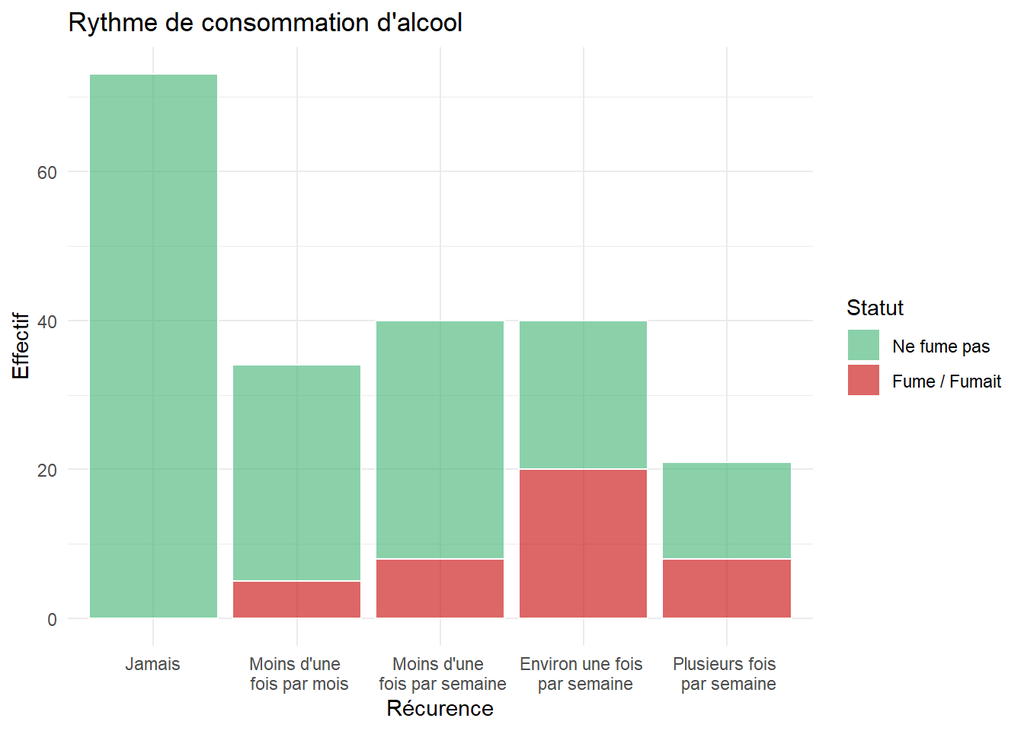

Nous pouvons donc nous demander si une forte régularité dans la consommation d’alcool est une des caractéristiques des fumeurs.

## 2.4 Nombre de soirées par semaine

Le nombre de soirées par semaine d’un étudiant pourrait donc donner des résultats similaires au tableau suivant, ce qui conforterait notre propos. Nous allons d’abord procéder à un tri pour retirer les valeurs qui gêneraient la visibilité du graphique, ce qui nous donne :

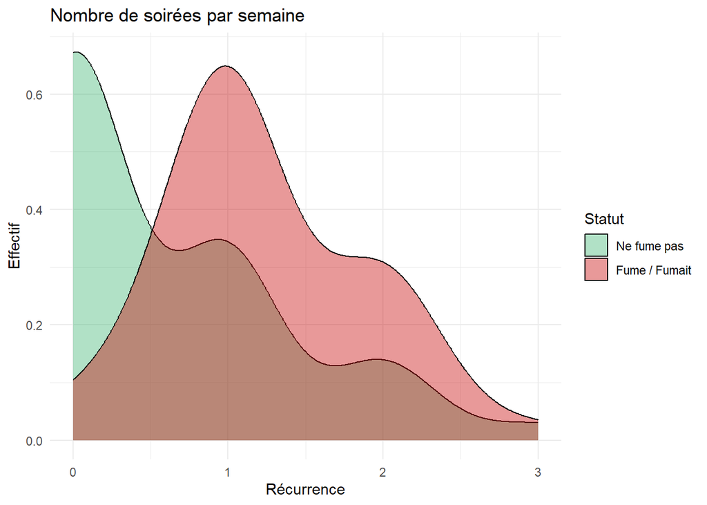

Le graphique représentant le nombre de soirées par semaine montre des résultats relativement similaires à ceux du graphique précédent, bien que ce dernier couvrait un mois complet. Nous observons un nombre élevé de fumeurs participant à entre 1 et 2 soirées par semaine, puisqu’ils représentent 81 % des fumeurs étudiés !

Il est important de noter que le nombre maximal de soirées par semaine atteint par un étudiant est de 4, et celui-ci est également un fumeur ! Sacré fêtard…

Nous retrouvons donc notre problématique également dans le cadre des soirées, à voir si cela est réellement significatif.

## 2.5 Temps de travail alloué par les étudiants

Revenons un peu sur les études et la rigueur des étudiants.

Voici un graphique en boîte représentant l’allocation du temps de travail en heures des étudiants sur une semaine complète. Nous avons supprimé les valeurs exorbitantes que certains sondés ont notées. Ainsi, les réponses indiquant plus de 70 % des 168 heures de la semaine ont été écartées afin de ne pas troubler les graphiques et par crainte que ces valeurs ne reflètent pas le mode de vie des étudiants.

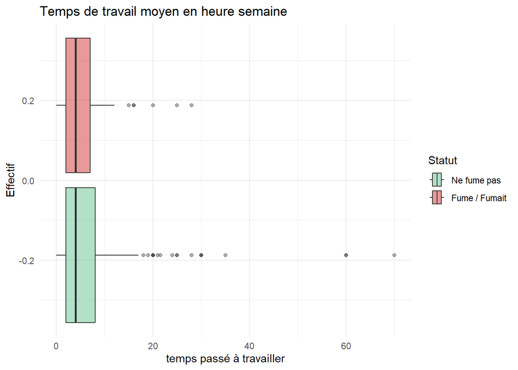

Les valeurs médianes des résultats varient toutes entre 2 et 4, cependant, les moyennes, les Q3 et les maximums ne sont pas identiques. La moyenne de temps passé à travailler pour un non-fumeur est de 7 heures et 25 minutes, contre 6 heures et 11 minutes pour un fumeur.

Le différentiel est donc de 74 minutes !

De plus, la personne ayant le plus de temps de travail parmi les fumeurs est une femme qui indique qu’elle travaille 28 heures par semaine, contre 70 heures par semaine pour le plus grand travailleur du sondage chez les non-fumeurs.

## 2.6 Résultats de la question du fumeur

Pour cette dernière étude, nous allons nous pencher sur les 10 questions de culture générale et sur les différences éventuelles entre les réponses des étudiants. On pourrait s’attendre à des résultats différents en raison du temps passé à étudier ou du temps passé en soirées.

Voici donc un tableau qui représente la répartition des notes des étudiants :

Pourcentage de réponses des étudiants

|  | 2 | 3 | 4 | 5 | 6 | 7 | 8 | 9 | 10 | Sum |
| --- | --- | --- | --- | --- | --- | --- | --- | --- | --- | --- |
| Ne fume pas | 0.48 | 0.96 | 1.92 | 7.69 | 14.42 | 19.23 | 17.79 | 13.94 | 3.85 | 80.29 |
| Fume / Fumait | 0.00 | 0.48 | 0.96 | 1.92 | 2.40 | 4.33 | 4.81 | 4.33 | 0.48 | 19.71 |
| Sum | 0.48 | 1.44 | 2.88 | 9.62 | 16.83 | 23.56 | 22.60 | 18.27 | 4.33 | 100.00 |

On constate que la majorité des réponses apportées par les non-fumeurs se situent entre 7 et 8 bonnes réponses au questionnaire, tandis que les fumeurs présentent une répartition plus variée, allant de 7 à 9 bonnes réponses.

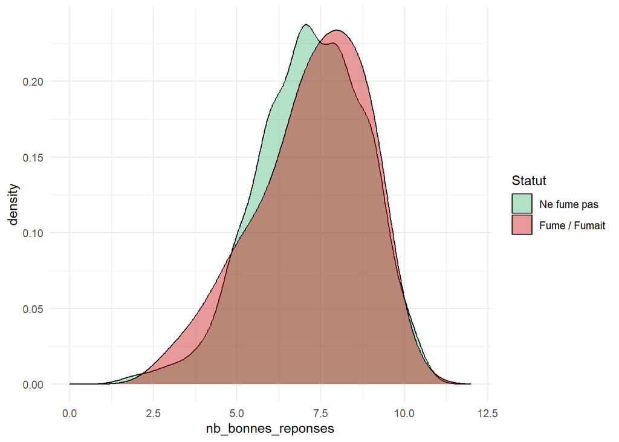

Le graphique montre un pic de bonnes réponses atteintes à des endroits différents selon le statut des étudiants. Les valeurs restent les mêmes, que les étudiants soient fumeurs ou non. La médiane 7 est identique à celle de 7, et la moyenne 7.2 est la même que 7.19.

Les résultats sont donc similaires, et nous pouvons déjà conclure que le statut de fumeur ne signifie pas que les résultats du questionnaire seront différents de ceux d’un non-fumeur.

# 3 Test de la problématique

Nous avons pu observer un bon nombre de données pour répondre à notre problématique. Cependant, pour répondre à la question, il est essentiel de vérifier si les variables avec lesquelles nous travaillons sont significatives et à quel point.

Nous les traiterons une par une en effectuant à chaque fois un test du Chi-2 pour déterminer leur indépendance vis-à-vis du statut de fumeur ou, au contraire, leur association avec ce dernier.

Avant toute chose, posons les hypothèses des tests qui nous permettront de conclure :

- **H0** : Indépendance entre les variables

- **H1** : Dépendance entre les variables

Pour toutes les observations, nous établirons un risque d’erreur de **0,05**.

Ainsi, avec un risque de **5 %**, nous conserverons l’hypothèse **H0** d’indépendance des variables si la p-value du test est supérieure.

### 3.0.1 Test du Genre

On observe que la p-value est de **0,6924**, ce qui est supérieur au risque de **0,05**.

Nous pouvons conclure que le genre n’est pas un facteur déterminant du statut de fumeur et qu’il ne devient pas déterminant en fonction du sexe.

### 3.0.2 Test de la spécialité

Ce test sera légèrement différent des autres, car nous allons non pas tester si le statut de fumeur est indépendant de la spécialité, mais plutôt comparer cette indépendance entre les spécialités littéraires et les spécialités scientifiques :

On observe que la p-value de la spécialité littéraire est de **0,7242**, ce qui est supérieur au risque de **0,05**, et la p-value de la spécialité scientifique est de **0,4696**.

Les deux p-values étant supérieures à **0,05**, nous conservons **H0**, ce qui signifie que le fait qu’un étudiant vienne d’une filière littéraire ou scientifique ne détermine pas son statut de fumeur, qui est indépendant de cette variable.

### 3.0.3 Test sur la consommation d’alcool

On observe que la p-value est de **2,31e-09**, ce qui est bien inférieur au risque de **0,05**.

### 3.0.4 Test sur le nombre de soirées

```
##
##  Pearson's Chi-squared test
##
## data:  data$`Nombre de soirées par semaine en moyenne` and data$fumeur
## X-squared = 37.745, df = 6, p-value = 1.26e-06
```

On observe que la p-value est de **1,26e-06**, ce qui est bien inférieur au risque de **0,05**.

Nous allons donc rejeter l’hypothèse **H0** et conserver **H1**.

Nous concluons qu’il existe une dépendance entre le statut de fumeur et le fait de sortir fréquemment en soirée dans la semaine.

### 3.0.5 Test sur le travail personnel fourni

On observe que la p-value est de **0,7953**, ce qui est supérieur au risque de **0,05**.

Ainsi, avec un risque de **5%**, nous conservons l’hypothèse **H0** d’indépendance entre les deux variables.

Nous pouvons conclure que le temps alloué au travail personnel n’est pas un facteur déterminant du statut de fumeur.

### 3.0.6 Test sur les résultats de culture générale

On observe que la p-value est de **0,9416**, ce qui est supérieur au risque de **0,05**.

Ainsi, avec un risque de **5%**, nous conservons l’hypothèse **H0** d’indépendance entre les deux variables.

Nous concluons que le nombre de bonnes réponses au test n’est pas dépendant du fait d’être fumeur ou non.

# 4 Conclusion

En choisissant cette problématique, notre première pensée s’est tournée vers ses implications au sein de la vie étudiante et de leurs intérêts pour les études.

Finalement, après de nombreuses analyses de graphiques, de tableaux et des tests d’indépendance, nous sommes parvenus à la conclusion suivante :

**- Le fumeur peut être autant une femme qu’un homme.**

**- Ce n’est pas parce que l’on vient d’une filière littéraire que l’on est automatiquement un fumeur.**

**- Le rythme de vie en dehors des études a un rapport avec la consommation de tabac.**